# Activity Montoring Data

## Loading and preprocessing the data

```r
activities <- read.csv("activity.csv", header=TRUE, sep=",", na.strings="NA")
activities$dt <- as.Date(activities$date)
summary(activities)
```

```
##      steps                date          interval            dt
##  Min.   :  0.00   2012-10-01:  288   Min.   :   0.0   Min.   :2012-10-01
##  1st Qu.:  0.00   2012-10-02:  288   1st Qu.: 588.8   1st Qu.:2012-10-16
##  Median :  0.00   2012-10-03:  288   Median :1177.5   Median :2012-10-31
##  Mean   : 37.38   2012-10-04:  288   Mean   :1177.5   Mean   :2012-10-31
##  3rd Qu.: 12.00   2012-10-05:  288   3rd Qu.:1766.2   3rd Qu.:2012-11-15
##  Max.   :806.00   2012-10-06:  288   Max.   :2355.0   Max.   :2012-11-30
##  NA's   :2304     (Other)   :15840
```

## What is mean total number of steps taken per day?

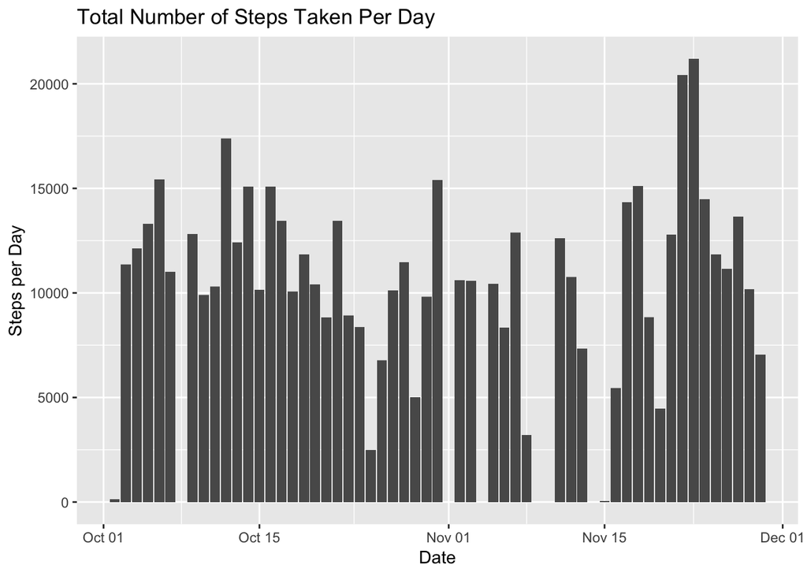

```r
library(ggplot2)
ggplot(activities, aes(dt, steps), fill=type) + geom_bar(stat = "identity") + labs(x="Date", y="Steps per Day", title = "Total Number of Steps Taken Per Day")
```

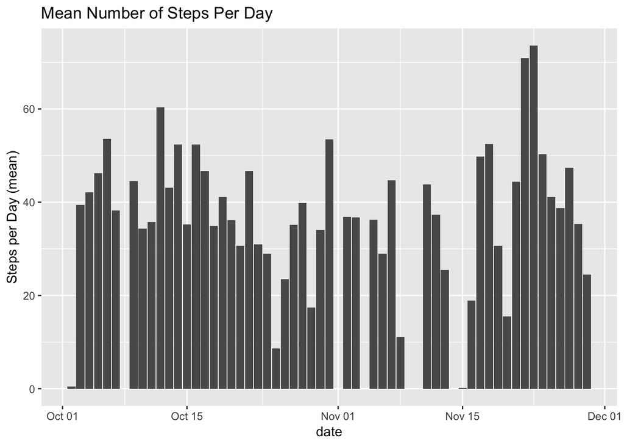

```r
ggplot(activities, aes(x=dt, y=steps), fill=type) + stat_summary(fun.y="mean", geom="bar") + labs(x="date", y="Steps per Day (mean)", title = "Mean Number of Steps Per Day")
```

[figure not shown]

```r
ggplot(activities, aes(x=dt, y=steps), fill=type) + stat_summary(fun.y="median", geom="bar") + labs(x="date", y="Steps per Day (median)", title = "Median Number of Steps Per Day")
```

```r
myFun <- function(x) {
     c(mean = mean(x), median = median(x))
}
activityMeanMedian <- tapply(activities$steps, activities$dt, myFun)
head(activityMeanMedian)
```

```
## $`2012-10-01`
##   mean median
##     NA     NA
##
## $`2012-10-02`
##   mean median
## 0.4375 0.0000
##
## $`2012-10-03`
##     mean   median
## 39.41667  0.00000
##
## $`2012-10-04`
##     mean   median
## 42.06944  0.00000
##
## $`2012-10-05`
##     mean   median
## 46.15972  0.00000
##
## $`2012-10-06`
##     mean   median
## 53.54167  0.00000
```

## What is the average daily activity pattern?

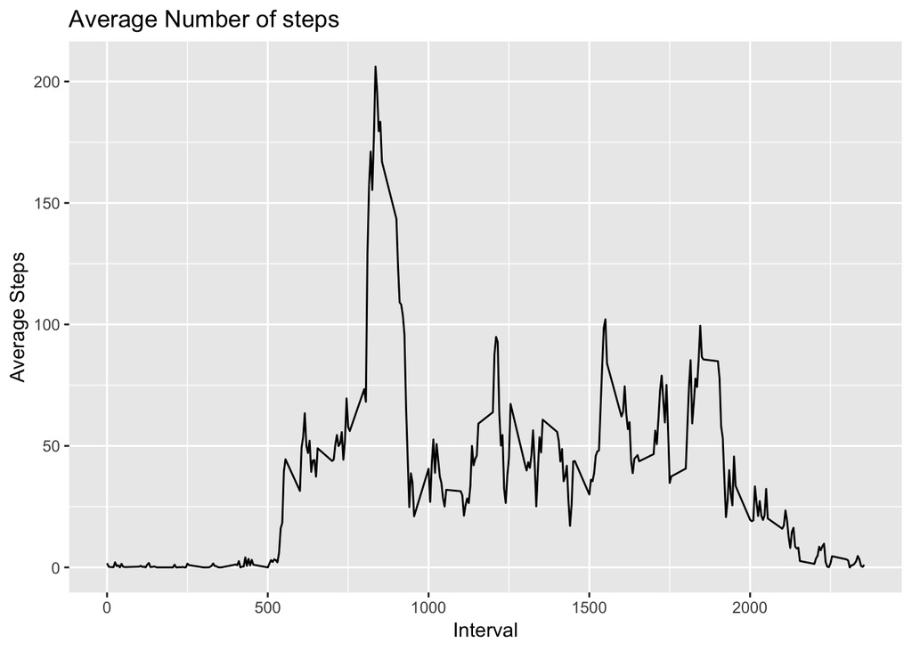

```r
library(plyr)
clean <- activities[!is.na(activities$steps),]
intervalTable <- ddply(clean, .(interval), summarize, Avg = mean(steps))
ggplot(intervalTable, aes(x=interval, y=Avg)) + geom_line() + labs(x="Interval", y="Average Steps", title="Average Number of steps")
```

```r
#Maximum steps by interval
maxSteps <- max(intervalTable$Avg)
#Which interval contains the maximum average number of steps
intervalTable[intervalTable$Avg==maxSteps,1]
```

```
## [1] 835
```

## Imputing missing values

#### 1. Calculate and report the total number of missing values in the dataset (i.e. the total number of rows with NA

```r
sum(is.na(activities$steps))
```

```
## [1] 2304
```

#### 2. Devise a strategy for filling in all of the missing values in the dataset. The strategy does not need to be sophisticated. For example, you could use the mean/median for that day, or the mean for that 5-minute interval, etc.

```r
activitiesFiltered <- na.omit(activities)
meanByInterval <- aggregate(activitiesFiltered[, 1], list(activitiesFiltered$interval), mean)
colnames(meanByInterval) <- c("interval", "mean")
activitiesMerge <- merge(activities, meanByInterval, by="interval")
activitesNa <- is.na(activitiesMerge$steps)
activitiesMerge[activitesNa,"steps"] <- activitiesMerge[activitesNa, "mean"]
```

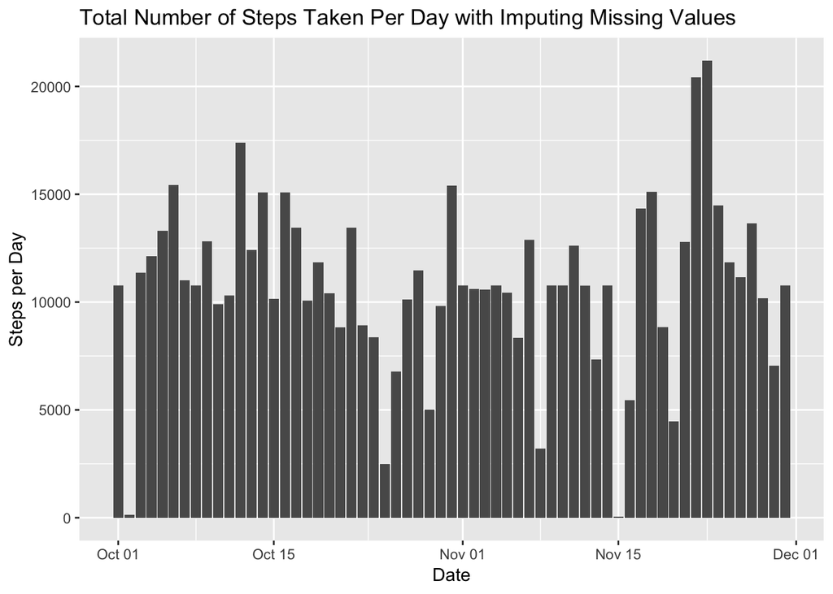

```r
ggplot(activitiesMerge, aes(dt, steps), fill=type) + geom_bar(stat = "identity") + labs(x="Date", y="Steps per Day", title = "Total Number of Steps Taken Per Day with Imputing Missing Values")
```

```r
activityMeanMergeMedian <- tapply(activitiesMerge$steps, activities$dt, myFun)
head(activityMeanMergeMedian)
```

```
## $`2012-10-01`
##      mean    median
## 0.5112683 0.0000000
##
## $`2012-10-02`
##     mean   median
## 1.010024 0.000000
##
## $`2012-10-03`
##      mean    median
## 0.3455189 0.0000000
##
## $`2012-10-04`
##      mean    median
## 0.6955582 0.0000000
##
## $`2012-10-05`
##      mean    median
## 0.2390592 0.0000000
##
## $`2012-10-06`
##      mean    median
## 0.2397799 0.0000000
```

## Are there differences in activity patterns between weekdays and weekends?

#### 1. Create a new factor variable in the dataset with two levels – “weekday” and “weekend” indicating whether a given date is a weekday or weekend day.

```r
library(dplyr)
library(lubridate)
is_weekday <-function(date){
        if(wday(date)%in%c(1,7)) result<-"weekend"
        else
                result<-"weekday"
        result
}
activitiesFiltered <- mutate(activitiesFiltered,date=ymd(date)) %>% mutate(day=sapply(date,is_weekday))
table(activitiesFiltered$day)
```

```
##
## weekday weekend
##   11232    4032
```

#### 2. Make a panel plot containing a time series plot (i.e. type=“l”) of the 5-minute interval (x-axis) and the average number of steps taken, averaged across all weekday days or weekend days (y-axis). See the README file in the GitHub repository to see an example of what this plot should look like using simulated data.

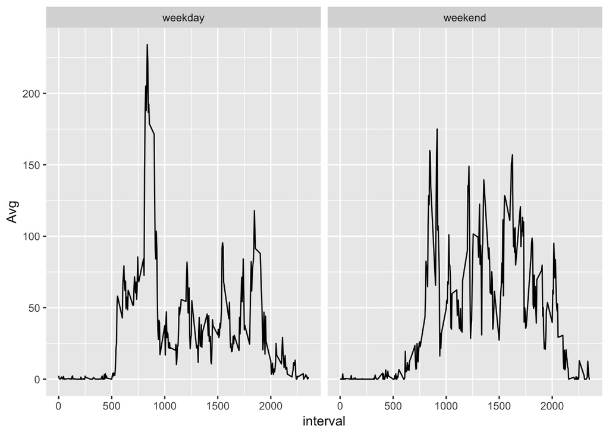

```r
intervalFilteredTable <- ddply(activitiesFiltered, .(interval, day), summarize, Avg = mean(steps))
ggplot(intervalFilteredTable, aes(x=interval, y=Avg)) + geom_line() + facet_grid(scales="free", space="free", .~day)
```